# Was Proto Oceanic society matrilineal?

Per Hage

Proto Oceanic society is believed to have developed in the region of the Bismarck Archipelago in western Melanesia around 1500 BC.[^1][^2] Within a few hundred years daughter societies expanded eastward into the rest of Melanesia and into nuclear Micronesia, eventually reaching the remotest islands of Polynesia by 1000 AD (Kirch 1997).[^3] Lexical reconstruction has revealed a great deal about Proto Oceanic economy, technology and material culture [Ross, Pawley and Osmond 1998][^4] but very little about aspects of social organisation. In particular there is considerable uncertainty about the type and even the existence of descent groups. My purpose is to suggest, through a combined analysis of historical linguistic, ethnographic and cross-cultural data, that POc society had unilineal, probably matrilineal descent groups and unilocal, probably matrilocal or matri-avunculocal residence rules.

Conjectures about descent groups in Proto Oceanic [read “early Oceanic”] society have a long history with contributions by anthropologists, linguists and archaeologists. Rivers (1914) assumed that early Melanesian society, like all early societies, was matrilineal on the grounds that only maternal kinship connections could be known for certain. He thought that matrilineal moiety systems developed early in Melanesian history as the result of a fusion between indigenous peoples and later arrivals, and he attributed shifts to patrilineal descent and succession to the influence of immigrants with an advanced culture. As M. Allen (1984:27) observed, Rivers’ argument was not really refuted, but simply “abandoned as a result of the general demise of evolutionary anthropology in favour of structural functionalism”. In a variation of Rivers’ scenario, Allen proposed that matrilineal descent groups were a precondition of social stratification in Melanesia, the argument being that that their restrictions on membership encouraged the formation of larger non-kinship political groups such as the graded societies of Vanuatu.

Several decades after Rivers, Murdock (1949) concluded from the application of an evolutionary algorithm that Proto Malayo-Polynesian and Proto Oceanic society were bilateral or “Hawaiian” in type and lacked descent groups of any kind. By Hawaiian, Murdock meant a cluster of traits including generational-Hawaiian kinship terminology, bilateral kindreds and bilocal extended families as well as the absence of unilineal descent groups. Goodenough (1955), noting that land tenure is generally associated with kinship groups in Malayo-Polynesian societies, amended Murdock’s conclusion by adding to it the feature of cognatic landholding descent groups. Linguistic evidence in support of Murdock’s reconstruction was provided by Milke (1958) who interpreted the basically generational-Hawaiian structure of POc kinship terminology, in which M = MZ = FZ and G = PGC as consistent with a bilateral form of social organisation.[^5] Evidence against the bilateral hypothesis was adduced by Blust (1980a) and Hage and Harary (1996) who showed that a strict application of Murdock’s algorithm leads to the conclusion that POc society was just as likely to have been “Iroquois” in type with either matrilineal or double descent.

In a recent work, Kirch (1997) proposed on general ethnographic grounds, that Lapita, i.e. Proto Oceanic, descent groups were cognatic in type:

> Social anthropologists have long been aware that Oceanic peoples do not organize themselves onto strict unilinear descent groups but rather tend to have more flexible cognatic (sometimes called “ambilinear” or “non-unilinear”) systems of descent reckoning” (Kirch 1997:189-90)

While it is true that there are many cognatic societies in Oceania, they do not predominate in all regions and where they do exist, they may not be a continuation of POc society but, rather, a later development.

In a linguistic approach to the problem, Pawley (1981) reconstructed a POc term *kainaŋa as meaning ‘descent group’ and, following Goodenough (1955) as ‘landholding descent group’ [but see §4.2.2.6]. However, Chowning (1991) objected that *kainaŋa may be attributable only to a lower-order branch of the Oceanic family tree and she argued that even if *kainaŋa, or an equivalent term *qapusa, could be attributed to POc,

> we would have no clue as to what kind of descent group or category might be represented. For the former, cognate terms designate a patrilineal group in Tikopia [a Polynesian outlier in Melanesia], a matrilineal one in Truk [in Micronesia] and a cognatic one in Maori [in Polynesia]. Furthermore, the kinship terms reconstructed so far for POc do not solve the problem. If POc had unilinear descent, we would expect either that a term for cross-cousin was reconstructable, or that many more of the societies would be like Truk and the Trobriands in having kinship systems (Crow, in these cases) that group cross-cousins with other kin types. I would also expect a reconstructable term for FaSi [father’s sister] unless, as in Kove, she was called by the same term as MoBro [mother’s brother], but this does not seem to happen in many Melanesian societies (Chowning 1991:70).

**Table 3.1** The relation between bifurcate merging kinship terminology and descent groups (Sources: Murdock 1967, 1970; Murdock and White 1969).

| Type of kinship terminology |  | Descent groups |  |
| --- | --- | --- | --- |
|  | Unilineal | Cognatic | Absent |
| Bifurcate merging (F = FB ≠ MB) | 47 | — | 8 |
| Other | 63 | 10 | 47 |

The case of a separate term for FZ is interesting and deserves a comment in view of its uncertain existence in POc, PPn and PMP kinship terminologies (Pawley 1981; Marck 1996; comments on Blust 1980a [and §2.5.1.2.6 of this volume]).[^9] In Oceanic the presence of a term for FZ almost always implies the presence of a term for MB. This is displayed in Table 3.3 which is based on the terminologies reported in Murdock (1970) for all the Oceanic-speaking societies in the World Ethnographic Atlas (WEA) (Murdock 1967).[^10] The implicational relationship between these two terms is an expression of a marking rule in which the presence of the marked term (FZ) implies the presence of the unmarked term (MB) but not necessarily conversely (Greenberg 1980).[^11] In most Oceanic as in most Polynesian and Malayo-Polynesian kinship terminologies (Hage 1996, 1998a; Hage and Harary 1996; Blust 1980a) ‘male’ is the unmarked term. Diachronically interpreted, if POc, PPn and PMP terminologies had a separate term for FZ it was lost before the term for MB.

**Table 3.2** The relation between bifurcate merging kinship terminology and residence rules (Sources: Murdock 1967, 1970; Murdock and White 1969).

| Type of kinship terminology |  |  |
| --- | --- | --- |
|  | Unilocal Residence | Non-unilocal Residence |
| Bifurcate merging (F = FB ≠ MB) | 49 | 5 |
| Other | 103 | 17 |

**Table 3.3** The relation between cross distinctions in ‘uncle’ terms and ‘aunt’ terms in Oceanic speaking societies. (Sources: Murdock 1967, 1970; Murdock and White 1969.)

|  | ‘Uncle’ terms: Cross distinction present | ‘Uncle’ terms: Cross distinction absent |
| --- | --- | --- |
| ‘Aunt’ terms: Cross distinction present | 13 | 1 |
| ‘Aunt’ terms: Cross distinction absent | 11 | 9 |

The evidence for matrilineal rather than patrilineal descent in Proto Oceanic society is distributional, linguistic and historical in nature. As Rivers (1914) and M. Allen (1984) emphasised, matrilineal descent groups are found extensively in many areas of Melanesia including

> the Huon Gulf, New Britain [east of the Willaumez Peninsula] and New Ireland [in the Bismarck Archipelago], the Massim Archipelago [apart from the northern d’Entrecasteaux], Bougainville, parts of the Solomons and much of north and central Vanuatu (M. Allen 1984:26). [Brackets are Hage’s]

Double descent groups are also found in Melanesia, e.g. Bunlap [Sa, south Pentecost] (Tattevin 1928), Vanua Levu [Fiji] (Quain 1948) and also in Micronesia, e.g. Pingelap (Damas 1979) and in Polynesia in Pukapuka (Beaglehole and Beaglehole 1938). If Murdock (1940, 1949) was right, one of the origins of double descent is the intrusion of patrilineal institutions into a strongly integrated matrilineal system. In a survey of double descent systems Murdock found that exogamy is everywhere associated with both matrilineal and patrilineal groups, but that inheritance and succession are almost always patrilineal. Residence is always patrilocal and political organisation is patrilineal.

In Table 3.4, all the Oceanic-speaking societies in the WEA are classified by type of descent group. In Polynesia, the last region of Oceanic settlement, descent groups are almost entirely cognatic; in nuclear Micronesia they are almost entirely matrilineal; and in Island Melanesia,[^12] the homeland of Proto Oceanic society, they are predominantly matrilineal or formerly matrilineal, as attested by systems of double descent.

**Table 3.4** Types of descent groups in Oceanic-speaking societies (Sources: Murdock 1967, 1970, Murdock and White 1969).

[output not shown]

With a larger sample of societies, the rows in Table 3.4 could specify major subgroups of the Oceanic language family. On the basis of available data in the WEA, matrilineal and double descent are not confined to societies in any one subgroup. It must be noted that anthropologists are sometimes uncertain about the existence of double descent, Thus Hogbin changed his mind about double descent in Wogeo, referring in 1970 to matrilineal moieties and agnatic residential groups. Schneider (1984) changed his earlier view of Yap (Schneider 1961) when he, most unfortunately, came to reject the entire metalanguage of kinship analysis.

Historical linguistic evidence for matrilineal descent in Proto Oceanic society is provided by Blust (1986-87) whose argument may be summarised. In the Austronesian languages terms for ‘orphan’ are in some cases monomorphemic as in Bontok so ‘be an orphan’ but in other cases descriptive as Malay *anak piatu* (*anak* ‘child, *piatu* ‘desolate, orphaned’). In some Oceanic languages the descriptive term refers to one or both parents. In a sample of 12 Oceanic languages, Blust found that in eight languages there is an agreement between the parent mentioned in the descriptive term and the rule of descent. For example, in Ere ‘orphan’ is timan *pwi* ‘father none’ and descent is patrilineal; in Woleaian ‘orphan’ is *sile-mas* and descent is matrilineal; in Samoan ‘orphan’ is *matua-oti* ‘parents dead’ and descent is ambilineal (cognatic). This correlation suggests that in Austronesian societies an orphan is defined in relation to his/her descent group rather than his/her parents. The four exceptions are Kwara’ae, Lau, ’Are’are and Sa’a, all of which are spoken in patrilineal societies in Malaita in the southeast Solomons. In all four languages there is a pair of terms reflecting Proto Malaita-Cristobal *tina mate ‘mother dead; and *tina mauri ‘mother living’ which refer to both parents, or to the father alone, and to persons of high and low status.

> It is noteworthy that a paired term reflecting earlier *tina mauri (“mother living”) is found widely in the Southeast Solomons (but not in Micronesia). Compare LAU (C.E. Fox 1974) *inamae*/*inomae* ‘orphan, relatives dead, poor and unprotected’, *inamauri*/*inomauri* ‘parents alive, prosperous, important’, *inamouri* ‘eldest son of a living chief’; (Catherine Tyhurst, pers. comm.) *inomae* ‘eldest son of a deceased man’, *faa-inomae* ‘to bereave’.—‘ARE’ARE (Geerts 1970) *inamae* ‘orphan’, *inamauri* ‘a very big chief, a person of very great importance’.—SA’A (Ivens 1929[a]) *inemae* ‘be an orphan, be bereft of parents, an orphan’, *inemauri* ‘be a chief, have a due succession of chiefs, a chief’.—AROSI (C.E. Fox 1970) *inemae* ‘child whose mother is dead, orphan’, *inemauri* ‘child whose mother is living’ (Blust 1986-87:220).

Blust interprets the discrepancy between the proto-term for ‘orphan’, and its reflexes as evidence for a shift from matrilineal to patrilineal descent in Malaita and by implication in the “wider Oceanic context”. Under this interpretation the correlation between lexical glosses of terms for ‘orphan’ and rules of descent in his sample of Oceanic-speaking societies is “exceptionless”.

Kinship systems are generally conservative in nature: they change slowly, sometimes glacially, under normal (non-acculturative) circumstances, and they are more resistant to diffusion than other cultural traits (Dyen and Aberle 1974; Eggan 1955; Murdock 1949). If Proto Oceanic society was, in fact, matrilineal then one might expect a continuation of matrilineal traits in its descendants. The converse would be true if Proto Oceanic society was patrilineal. Data for testing this hypothesis come from a recent study by Burton et al. (1996).

Burton and his colleagues, building on the work of Murdock (1967), have shown that nine world regions can be distinctively characterised by two dimensions of social structure: gender and descent. These two dimensions score 63 different traits of social structure.[^13] The first dimension contrasts matricentric and patricentric traits of social organisation and kinship terminology.

In order of strength from highly to weakly positive,

> [m]atricentric social organization traits include matrilocal or uxorilocal residence, monogamy, and the absence of marriage exchange.[^14] Hence, matricentric societies tend to organize kinship groups around women through matrilocal or uxorilocal residence or through matrilineal kinship groups (Burton et al. 1996:93)

In order of strength,

> [p]atricentric social organization traits include nomadic or seminomadic settlement patterns, clan communities, localized or dispersed patrilineal groups, patrilocal residence, polygyny, and bridewealth payments. Hence, patricentic societies tend to organize kin groups around men through patrilocal residence, patrilineal descent or polygyny… Strongly matricentric kinship terminologies include generational aunt terms, bifurcate merging aunt terms and Crow cousin terms. The former two terminologies classify mother and mother’s sister together, as one would expect of societies that keep related women together after marriage, and Crow cousin terms are well known to be associated with matrilineal descent. Strongly patricentric kinship terminologies include bifurcate collateral aunt terms and Omaha cousin terms. Bifurcate collateral terminologies assign separate terms to mother and mother’s sister, as one would expect of societies that separate women after marriage, and Omaha terms are well known to be associated with patrilineal descent.

> The second dimension…contrasts unilineal and bilateral traits… Unilineal social organization traits include clan communities, dispersed or localized patrilineal groups, dispersed matrilineal groups, patrilocal residence, nonsororal polygyny, cousin marriage, patrilocal residence, and bridewealth payments. Bilateral social organization traits include bilateral kin groups, ego-centered kindreds, virilocal residence, bilocal residence, monogamy, and prohibition of cousin marriages.

Applying the method of correspondence analysis (Greenacre 1984) these two dimensions define a space in which societies can be located by their social structural traits. Halves of this space are matricentric versus patricentric and unilineal versus bilateral, while quadrants are matricentric and bilateral versus matricentric and unilineal, and so on. Two of the nine world regions identified by Burton et al. are the Southeast Asia and the Insular Pacific (Micronesia and Polynesia) region, which is matricentric, and the Australia, New Guinea and Melanesia region, which is unilineal. Since the authors give the rating on each dimension for every society in their world-wide sample, it is possible to define a region strictly by language group. We will consider only the Oceanic-speaking societies in Polynesia, Nuclear Micronesia and Melanesia, cross-cutting the two worlds just mentioned.

If Proto Oceanic society was strongly matrilineal, one would expect to find a continuation of matricentric traits in its descendants, including those that later developed different descent rules. Support for this hypothesis is given in Figure 3.1. With two exceptions (Seniang [Sinesip] and Lau, Fiji) all the Oceanic-speaking societies in the WEA are matricentric whatever their rule of descent—cognatic, patrilineal, matrilineal or double descent.

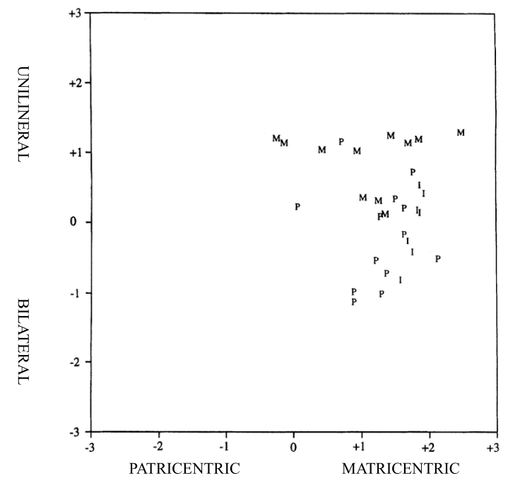

**Figure 3.1:** Social structural traits of Oceanic-speaking societies (based on Burton et_al. 1996. M= Melanesia, P= Polynesia, I= Micronesia)

We conclude, on the basis of historical-linguistic, ethnographic and cross-cultural evidence, that descent in Proto Oceanic society was matrilineal and residence matrilocal or matri-avunculocal. This result would account for certain unusual ethnographic facts, such as the presence of Crow kinship terminology and patrilineal descent in Seniang [Sinesip] (a case in which changes in kinship terminology, as usual, lag behind changes in descent), marriage with the MBW (Rivers 1914) (a practice commonly found in matrilineal societies of generalised exchange; Lévi-Strauss 1969, Hage 1998b), and double descent (the undermining of a strongly integrated matrilineal system by patrilineal institutions).

It may be, as Lane (1961) and Dole (1967) have argued, that demographic and geographic constraints—small unstable populations and great distances—led to the development of more flexible cognatic social organisation in the settlement of Polynesia. It may also be the case that relative isolation after settlement led to the weakening or disappearance of matrilineal descent in some Oceanic societies. As Lévi-Strauss (1984:183) observed with respect to Micronesia, in those societies that have lived in relative isolation, “we find…a retreat from matrilineal institutions: left to themselves these institutions, by reason of their well-known instability, have a tendency to evolve spontaneously towards other forms.” Damas (1979) makes this point with respect to isolated atolls in the Carolines—Pingelap, Mokil and Ngatik—where matrilineal descent was left with few functions other than exogamy:

> I would argue that the comparative vitality of matrilineal emphasis in the Yap and Truk districts is closely related to regular reinforcement of those ties through the process of clientship, trade relations, and (in the case of Yap) a system of tribute which operated largely within a matrilineal context. By contrast, relative isolation of the atolls and islands in the eastern Carolines appears to have promoted conditions which serve to weaken matriliny (Damas 1979:192).

One should also mention here the two isolated outliers, Enewetok and Ujelang, in the solidly matrilineal Marshall Islands which evolved patrilineal descent groups (moieties) (Hage and Harary 1996). According to Ann Chowning (pers. comm.) the majority of Oceanic-speaking societies in the New Guinea mainland are patrilineal rather than matrilineal. In this case, rugged terrain rather than geographical distance was a barrier to social communication which led to the weakening or disappearance of matrilineal institutions.

The hypothesis of matrilineal Proto Oceanic social organisation should have interesting culture historical implications. Rivers, as mentioned, attributed moiety systems, which are common in Melanesia, to the fusion of indigenous and immigrant peoples. As evidence he noted the presence of inter-moiety hostility, native traditions of separate origins and the attribution of physical and mental differences to members of different moieties. As Blust (1981c) has observed, there is no linguistic evidence for the “fusion hypothesis”, i.e., no significant differences in vocabulary, phonology or grammar between members of different moieties in Oceanic societies. An alternative, more plausible explanation, which applies to moiety systems in general, derives from a theory of Murdock’s (1940, 1949). Typically, when a matrilineal society fissions, the new community, in order to preserve the proximity of males to their natal groups, consists of two exogamous lineages. Eventually these two groups may develop onto a moiety system with all its attendant symbolism. Could such a process account for the prevalence of moiety systems in Melanesia?[^15]

## Notes

[^1]: This is a slightly edited and abridged version of a paper first published in The Journal of the Polynesian Society 107:365-379 (2007). The editors thank Andrea Hage for permission to reproduce the paper.
[^2]: The author wishes to thank Robert Blust and Ann Chowning for their most helpful comments on a draft of this paper. Responsibility is, of course, solely his own. The research was supported in part by a grant from the National Science Foundation.
[^3]: [Recent archaeology suggests 1300 BC instead of 1500 BC, and 1300 AD instead of 1000 AD (Reith & Cochrane 2018).]
[^4]: [Square brackets enclose editorial insertions.]
[^5]: The following kinship abbreviations are used in this paper: F = father, M = mother, B= brother, Z = sister, G = sibling, S = son, D = daughter, ss = same sex as ego, os = opposite sex from ego, FB = father’s brother, MB = mother’s brother, etc; +1 = first ascending generation.
[^6]: The association between bifurcate merging female relations, including the triad M = MZ ≠ FZ, and unilineal descent and unilocal residence was demonstrated long ago by Murdock (1947, 1949). It was also deduced by Rivers (1914).
[^7]: Tables 3.1 and 3.2 are based on Murdock and White’s (1969) Standard Cross-Cultural Sample. This consists of 186 societies chosen from 200 world sampling provinces (Murdock 1968b). Tables 3.1 and 3.2 show a smaller number of societies owing to the absence of data or to questions about the coding of kin terms (in Murdock 1970), descent rules and residence rules (in Murdock 1967) and the lack of alternative societies from the same sampling province.
[^8]: That is, with patri-, viri-, matri-, uxori-, avuncu- or natolocal residence. In Table 3.2, societies are coded for the dominant or permanent rule of residence indicated by a capital letter in Column 16 of the World Ethnographic Atlas.
[^9]: There is an extensive literature on the special position of the FZ in Oceanic societies, including Rivers (1910), Mead (1934), Mabuchi (1964), Rogers (1977) and Douaire-Marsaudon (1996).
[^10]: In Tables 3.3 and 3.4, Yap is counted as an Oceanic society (Ross 1996).
[^11]: An extended application of marking theory to kinship terminology is given in Hage (1999b).
[^12]: The great majority of Oceanic-speaking societies in Melanesia are in Island Melanesia and are the only ones included in the WEA. In the Encyclopedia of World Cultures, vol. 2, Oceania, [Hays 1991] five mainland New Guinea Oceanic-speaking societies are represented: four (Mekeo, Motu, Maisin and Sio) are patrilineal and one (Wamira [= Bartle Bay dialect of Wedau]) is matrilineal. In distinguishing Oceanic from non-Austronesian-speaking societies in Melanesia one should not overlook the effects of interaction between these groups, as Green (1991a) and Kirch (1997) have emphasised in archaeological studies. In cultural anthropology, Chowning (pers. comm.) notes an interesting historical connection between them: “At least in East New Britain and on Bougainville, the [non-Austronesian]-speaking societies, whose ancestors presumably arrived there long before the [Oceanic] speakers, are also matrilineal… [I]n the matrilineal arc that extends from the Massim up through Bougainville and across to New Britain, matrilinearity, regardless of language affiliation, is associated with the belief that the lines in the palms of the hands designate the bird tabu to the descent group.” See Chowning 1982.
[^13]: According to Burton et al (1996:93), “the scores are similar to factor loadings but are standardised differently and therefore have a different range.” A plot of all 63 traits is given in Whiting et al. (1988).
[^14]: In Column 12 of the WEA, “Mode of marriage”, “marriage exchange” refers to the ‘transfer of a sister or other female relative of the groom in exchange for the bride’. “Bridewealth (or brideprice)” refers to the ‘transfer of a substantial consideration in the form of livestock, goods, or money from the groom or his relatives to the kinsmen of the bride’ (Murdock 1967:47).
[^15]: Under Blust’s (1981c) hypothesis that dual organisation was a feature of Proto Malayo-Polynesian society which continued in many Oceanic societies, the two groups would be lineages belonging to different moieties or lineages of the same moiety which became exogamous.